```python
import numpy as np
import pandas as pd
from bokeh.plotting import figure, show, save
from bokeh.io import output_notebook
from bokeh.charts import Bar
from bokeh.palettes import inferno,plasma, viridis
from bokeh.models import Legend
from bokeh.charts import Histogram
import matplotlib.pyplot as plt
import seaborn as sn
%matplotlib inline
import os.path
```

# Reading the data

```python
path_1 =  "../DataScience_Task/day.csv"
path_2 =  "../DataScience_Task/hour.csv"
df_day = pd.read_csv(path_1, parse_dates = ['dteday'])
df_hour = pd.read_csv(path_2, parse_dates = ['dteday'])
```

# Analyze the day data

```python
print('\n first 5 rows of the day data:\n\n')
df_day.head()
```

```
 first 5 rows of the day data:
```

|  | instant | dteday | season | yr | mnth | holiday | weekday | workingday | weathersit | temp | atemp | hum | windspeed | casual | registered | cnt |
| --- | --- | --- | --- | --- | --- | --- | --- | --- | --- | --- | --- | --- | --- | --- | --- | --- |
| 0 | 1 | 2011-01-01 | 1 | 0 | 1 | 0 | 6 | 0 | 2 | 0.344167 | 0.363625 | 0.805833 | 0.160446 | 331 | 654 | 985 |
| 1 | 2 | 2011-01-02 | 1 | 0 | 1 | 0 | 0 | 0 | 2 | 0.363478 | 0.353739 | 0.696087 | 0.248539 | 131 | 670 | 801 |
| 2 | 3 | 2011-01-03 | 1 | 0 | 1 | 0 | 1 | 1 | 1 | 0.196364 | 0.189405 | 0.437273 | 0.248309 | 120 | 1229 | 1349 |
| 3 | 4 | 2011-01-04 | 1 | 0 | 1 | 0 | 2 | 1 | 1 | 0.200000 | 0.212122 | 0.590435 | 0.160296 | 108 | 1454 | 1562 |
| 4 | 5 | 2011-01-05 | 1 | 0 | 1 | 0 | 3 | 1 | 1 | 0.226957 | 0.229270 | 0.436957 | 0.186900 | 82 | 1518 | 1600 |

```python
print('\n statistics of the day data:\n\n ')
df_day.describe()
```

```
 statistics of the day data:
```

|  | instant | season | yr | mnth | holiday | weekday | workingday | weathersit | temp | atemp | hum | windspeed | casual | registered | cnt |
| --- | --- | --- | --- | --- | --- | --- | --- | --- | --- | --- | --- | --- | --- | --- | --- |
| count | 731.000000 | 731.000000 | 731.000000 | 731.000000 | 731.000000 | 731.000000 | 731.000000 | 731.000000 | 731.000000 | 731.000000 | 731.000000 | 731.000000 | 731.000000 | 731.000000 | 731.000000 |
| mean | 366.000000 | 2.496580 | 0.500684 | 6.519836 | 0.028728 | 2.997264 | 0.683995 | 1.395349 | 0.495385 | 0.474354 | 0.627894 | 0.190486 | 848.176471 | 3656.172367 | 4504.348837 |
| std | 211.165812 | 1.110807 | 0.500342 | 3.451913 | 0.167155 | 2.004787 | 0.465233 | 0.544894 | 0.183051 | 0.162961 | 0.142429 | 0.077498 | 686.622488 | 1560.256377 | 1937.211452 |
| min | 1.000000 | 1.000000 | 0.000000 | 1.000000 | 0.000000 | 0.000000 | 0.000000 | 1.000000 | 0.059130 | 0.079070 | 0.000000 | 0.022392 | 2.000000 | 20.000000 | 22.000000 |
| 25% | 183.500000 | 2.000000 | 0.000000 | 4.000000 | 0.000000 | 1.000000 | 0.000000 | 1.000000 | 0.337083 | 0.337842 | 0.520000 | 0.134950 | 315.500000 | 2497.000000 | 3152.000000 |
| 50% | 366.000000 | 3.000000 | 1.000000 | 7.000000 | 0.000000 | 3.000000 | 1.000000 | 1.000000 | 0.498333 | 0.486733 | 0.626667 | 0.180975 | 713.000000 | 3662.000000 | 4548.000000 |
| 75% | 548.500000 | 3.000000 | 1.000000 | 10.000000 | 0.000000 | 5.000000 | 1.000000 | 2.000000 | 0.655417 | 0.608602 | 0.730209 | 0.233214 | 1096.000000 | 4776.500000 | 5956.000000 |
| max | 731.000000 | 4.000000 | 1.000000 | 12.000000 | 1.000000 | 6.000000 | 1.000000 | 3.000000 | 0.861667 | 0.840896 | 0.972500 | 0.507463 | 3410.000000 | 6946.000000 | 8714.000000 |

```python
print('\n pairwise correlation of different features in the day data:\n\n {}'.format(df_day.corr()))
```

```
 pairwise correlation of different features in the day data:

              instant    season        yr      mnth   holiday   weekday  \
instant     1.000000  0.412224  0.866025  0.496702  0.016145 -0.000016
season      0.412224  1.000000 -0.001844  0.831440 -0.010537 -0.003080
yr          0.866025 -0.001844  1.000000 -0.001792  0.007954 -0.005461
mnth        0.496702  0.831440 -0.001792  1.000000  0.019191  0.009509
holiday     0.016145 -0.010537  0.007954  0.019191  1.000000 -0.101960
weekday    -0.000016 -0.003080 -0.005461  0.009509 -0.101960  1.000000
workingday -0.004337  0.012485 -0.002013 -0.005901 -0.253023  0.035790
weathersit -0.021477  0.019211 -0.048727  0.043528 -0.034627  0.031087
temp        0.150580  0.334315  0.047604  0.220205 -0.028556 -0.000170
atemp       0.152638  0.342876  0.046106  0.227459 -0.032507 -0.007537
hum         0.016375  0.205445 -0.110651  0.222204 -0.015937 -0.052232
windspeed  -0.112620 -0.229046 -0.011817 -0.207502  0.006292  0.014282
casual      0.275255  0.210399  0.248546  0.123006  0.054274  0.059923
registered  0.659623  0.411623  0.594248  0.293488 -0.108745  0.057367
cnt         0.628830  0.406100  0.566710  0.279977 -0.068348  0.067443

            workingday  weathersit      temp     atemp       hum  windspeed  \
instant      -0.004337   -0.021477  0.150580  0.152638  0.016375  -0.112620
season        0.012485    0.019211  0.334315  0.342876  0.205445  -0.229046
yr           -0.002013   -0.048727  0.047604  0.046106 -0.110651  -0.011817
mnth         -0.005901    0.043528  0.220205  0.227459  0.222204  -0.207502
holiday      -0.253023   -0.034627 -0.028556 -0.032507 -0.015937   0.006292
weekday       0.035790    0.031087 -0.000170 -0.007537 -0.052232   0.014282
workingday    1.000000    0.061200  0.052660  0.052182  0.024327  -0.018796
weathersit    0.061200    1.000000 -0.120602 -0.121583  0.591045   0.039511
temp          0.052660   -0.120602  1.000000  0.991702  0.126963  -0.157944
atemp         0.052182   -0.121583  0.991702  1.000000  0.139988  -0.183643
hum           0.024327    0.591045  0.126963  0.139988  1.000000  -0.248489
windspeed    -0.018796    0.039511 -0.157944 -0.183643 -0.248489   1.000000
casual       -0.518044   -0.247353  0.543285  0.543864 -0.077008  -0.167613
registered    0.303907   -0.260388  0.540012  0.544192 -0.091089  -0.217449
cnt           0.061156   -0.297391  0.627494  0.631066 -0.100659  -0.234545

              casual  registered       cnt
instant     0.275255    0.659623  0.628830
season      0.210399    0.411623  0.406100
yr          0.248546    0.594248  0.566710
mnth        0.123006    0.293488  0.279977
holiday     0.054274   -0.108745 -0.068348
weekday     0.059923    0.057367  0.067443
workingday -0.518044    0.303907  0.061156
weathersit -0.247353   -0.260388 -0.297391
temp        0.543285    0.540012  0.627494
atemp       0.543864    0.544192  0.631066
hum        -0.077008   -0.091089 -0.100659
windspeed  -0.167613   -0.217449 -0.234545
casual      1.000000    0.395282  0.672804
registered  0.395282    1.000000  0.945517
cnt         0.672804    0.945517  1.000000
```

```python
print('Do we have any missing values in our day data?\n')
df_day.isnull().sum()
```

```
Do we have any missing values in our day data?
```

```
instant       0
dteday        0
season        0
yr            0
mnth          0
holiday       0
weekday       0
workingday    0
weathersit    0
temp          0
atemp         0
hum           0
windspeed     0
casual        0
registered    0
cnt           0
dtype: int64
```

```python
df_day.info()
```

```
<class 'pandas.core.frame.DataFrame'>
RangeIndex: 731 entries, 0 to 730
Data columns (total 16 columns):
instant       731 non-null int64
dteday        731 non-null datetime64[ns]
season        731 non-null int64
yr            731 non-null int64
mnth          731 non-null int64
holiday       731 non-null int64
weekday       731 non-null int64
workingday    731 non-null int64
weathersit    731 non-null int64
temp          731 non-null float64
atemp         731 non-null float64
hum           731 non-null float64
windspeed     731 non-null float64
casual        731 non-null int64
registered    731 non-null int64
cnt           731 non-null int64
dtypes: datetime64[ns](1), float64(4), int64(11)
memory usage: 91.5 KB
```

```python
print('Do we have any missing values in our day data?\n')
df_hour.isnull().sum()
```

```
Do we have any missing values in our day data?
```

```
instant       0
dteday        0
season        0
yr            0
mnth          0
hr            0
holiday       0
weekday       0
workingday    0
weathersit    0
temp          0
atemp         0
hum           0
windspeed     0
casual        0
registered    0
cnt           0
dtype: int64
```

## Box plots

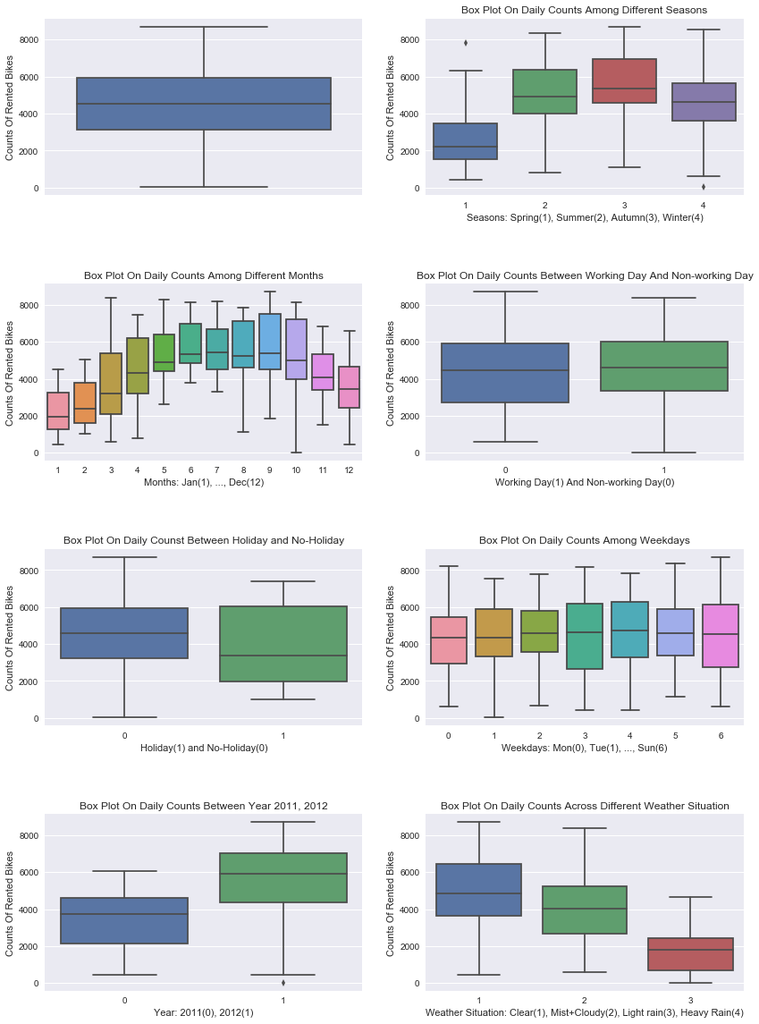

```python
fig, axes = plt.subplots(nrows=4,ncols=2)
fig.set_size_inches(14, 20)
sn.boxplot(data=df_day, x="cnt", orient="v", ax=axes[0][0])
sn.boxplot(data=df_day, y="cnt", x="season", orient="v", ax=axes[0][1] )
sn.boxplot(data=df_day, y="cnt", x="mnth", orient="v", ax=axes[1][0])
sn.boxplot(data=df_day, y="cnt", x="workingday", orient="v", ax=axes[1][1])
sn.boxplot(data=df_day, y="cnt", x="holiday", orient="v", ax=axes[2][0] )
sn.boxplot(data=df_day, y="cnt", x="weekday", orient="v", ax=axes[2][1])
sn.boxplot(data=df_day, y="cnt", x="yr", orient="v", ax=axes[3][0] )
sn.boxplot(data=df_day, y="cnt", x="weathersit", orient="v", ax=axes[3][1])

axes[0][0].set(ylabel='Counts Of Rented Bikes')
axes[0][1].set(xlabel='Seasons: Spring(1), Summer(2), Autumn(3), Winter(4)', ylabel='Counts Of Rented Bikes', title="Box Plot On Daily Counts Among Different Seasons")
axes[1][0].set(xlabel='Months: Jan(1), ..., Dec(12)', ylabel='Counts Of Rented Bikes', title="Box Plot On Daily Counts Among Different Months")
axes[1][1].set(xlabel='Working Day(1) And Non-working Day(0)', ylabel='Counts Of Rented Bikes', title="Box Plot On Daily Counts Between Working Day And Non-working Day")
axes[2][0].set(xlabel='Holiday(1) and No-Holiday(0)', ylabel='Counts Of Rented Bikes', title='Box Plot On Daily Counst Between Holiday and No-Holiday')
axes[2][1].set(xlabel='Weekdays: Mon(0), Tue(1), ..., Sun(6)', ylabel = 'Counts Of Rented Bikes', title='Box Plot On Daily Counts Among Weekdays')
axes[3][0].set(xlabel='Year: 2011(0), 2012(1)', ylabel='Counts Of Rented Bikes', title='Box Plot On Daily Counts Between Year 2011, 2012')
axes[3][1].set(xlabel='Weather Situation: Clear(1), Mist+Cloudy(2), Light rain(3), Heavy Rain(4)', ylabel = 'Counts Of Rented Bikes', title='Box Plot On Daily Counts Across Different Weather Situation')
plt.subplots_adjust(hspace = 0.5)
```

#### To get an insight about the datasets and finding out if my data-sets have outliers, I used box plot to visualize the spread of day and hour datasets.

#### As we can see, for the day data-set we have:

- The average rented bikes in the year 2012 is higher than year 2011.
- The average number of rented bikes is higher during Summer and Autumn. This we can also see on the box plot for months. From May till October on average users (casual and registered) rented more bikes compared to other months.
- On average users rent more bikes when there is no holiday.
- On average the number of rented bikes is almost equal during different days of a week.
- On average users rent more bikes when the weather is clear. As the weather gets worse, the average number of users also decrease.

## Histogram for the daily counts of rented biked

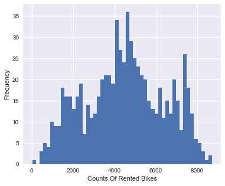

```python
plt.figure(figsize=[6,5])
plt.hist(df_day['cnt'], bins=50)
plt.xlabel('Counts Of Rented Bikes')
plt.ylabel('Frequency')
plt.show()
```

## Correlation matrix for day dataset

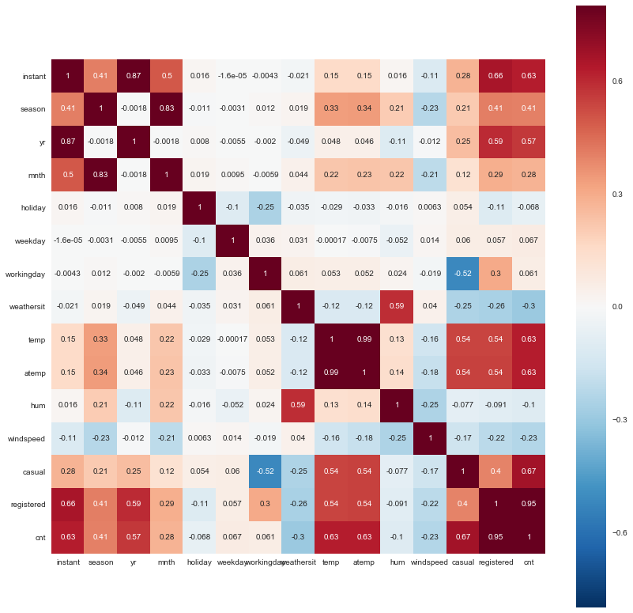

```python
corr = df_day.corr()

mask = np.zeros_like(corr, dtype=np.bool)
mask[np.triu_indices_from(mask)] = False

f, ax = plt.subplots(figsize=(14, 14))
sn.heatmap(corr, mask=mask, vmax=.8, square=True, annot=True)
```

# Analyze the hour data

```python
print('\n first 5 rows of the day data:\n\n')
df_hour.head()
```

```
 first 5 rows of the day data:
```

|  | instant | dteday | season | yr | mnth | hr | holiday | weekday | workingday | weathersit | temp | atemp | hum | windspeed | casual | registered | cnt |
| --- | --- | --- | --- | --- | --- | --- | --- | --- | --- | --- | --- | --- | --- | --- | --- | --- | --- |
| 0 | 1 | 2011-01-01 | 1 | 0 | 1 | 0 | 0 | 6 | 0 | 1 | 0.24 | 0.2879 | 0.81 | 0.0 | 3 | 13 | 16 |
| 1 | 2 | 2011-01-01 | 1 | 0 | 1 | 1 | 0 | 6 | 0 | 1 | 0.22 | 0.2727 | 0.80 | 0.0 | 8 | 32 | 40 |
| 2 | 3 | 2011-01-01 | 1 | 0 | 1 | 2 | 0 | 6 | 0 | 1 | 0.22 | 0.2727 | 0.80 | 0.0 | 5 | 27 | 32 |
| 3 | 4 | 2011-01-01 | 1 | 0 | 1 | 3 | 0 | 6 | 0 | 1 | 0.24 | 0.2879 | 0.75 | 0.0 | 3 | 10 | 13 |
| 4 | 5 | 2011-01-01 | 1 | 0 | 1 | 4 | 0 | 6 | 0 | 1 | 0.24 | 0.2879 | 0.75 | 0.0 | 0 | 1 | 1 |

```python
print('\n statistics of the hour data:\n\n ')
df_hour.describe()
```

```
 statistics of the hour data:
```

|  | instant | season | yr | mnth | hr | holiday | weekday | workingday | weathersit | temp | atemp | hum | windspeed | casual | registered | cnt |
| --- | --- | --- | --- | --- | --- | --- | --- | --- | --- | --- | --- | --- | --- | --- | --- | --- |
| count | 17379.0000 | 17379.000000 | 17379.000000 | 17379.000000 | 17379.000000 | 17379.000000 | 17379.000000 | 17379.000000 | 17379.000000 | 17379.000000 | 17379.000000 | 17379.000000 | 17379.000000 | 17379.000000 | 17379.000000 | 17379.000000 |
| mean | 8690.0000 | 2.501640 | 0.502561 | 6.537775 | 11.546752 | 0.028770 | 3.003683 | 0.682721 | 1.425283 | 0.496987 | 0.475775 | 0.627229 | 0.190098 | 35.676218 | 153.786869 | 189.463088 |
| std | 5017.0295 | 1.106918 | 0.500008 | 3.438776 | 6.914405 | 0.167165 | 2.005771 | 0.465431 | 0.639357 | 0.192556 | 0.171850 | 0.192930 | 0.122340 | 49.305030 | 151.357286 | 181.387599 |
| min | 1.0000 | 1.000000 | 0.000000 | 1.000000 | 0.000000 | 0.000000 | 0.000000 | 0.000000 | 1.000000 | 0.020000 | 0.000000 | 0.000000 | 0.000000 | 0.000000 | 0.000000 | 1.000000 |
| 25% | 4345.5000 | 2.000000 | 0.000000 | 4.000000 | 6.000000 | 0.000000 | 1.000000 | 0.000000 | 1.000000 | 0.340000 | 0.333300 | 0.480000 | 0.104500 | 4.000000 | 34.000000 | 40.000000 |
| 50% | 8690.0000 | 3.000000 | 1.000000 | 7.000000 | 12.000000 | 0.000000 | 3.000000 | 1.000000 | 1.000000 | 0.500000 | 0.484800 | 0.630000 | 0.194000 | 17.000000 | 115.000000 | 142.000000 |
| 75% | 13034.5000 | 3.000000 | 1.000000 | 10.000000 | 18.000000 | 0.000000 | 5.000000 | 1.000000 | 2.000000 | 0.660000 | 0.621200 | 0.780000 | 0.253700 | 48.000000 | 220.000000 | 281.000000 |
| max | 17379.0000 | 4.000000 | 1.000000 | 12.000000 | 23.000000 | 1.000000 | 6.000000 | 1.000000 | 4.000000 | 1.000000 | 1.000000 | 1.000000 | 0.850700 | 367.000000 | 886.000000 | 977.000000 |

```python
df_hour.info()
```

```
<class 'pandas.core.frame.DataFrame'>
RangeIndex: 17379 entries, 0 to 17378
Data columns (total 17 columns):
instant       17379 non-null int64
dteday        17379 non-null datetime64[ns]
season        17379 non-null int64
yr            17379 non-null int64
mnth          17379 non-null int64
hr            17379 non-null int64
holiday       17379 non-null int64
weekday       17379 non-null int64
workingday    17379 non-null int64
weathersit    17379 non-null int64
temp          17379 non-null float64
atemp         17379 non-null float64
hum           17379 non-null float64
windspeed     17379 non-null float64
casual        17379 non-null int64
registered    17379 non-null int64
cnt           17379 non-null int64
dtypes: datetime64[ns](1), float64(4), int64(12)
memory usage: 2.3 MB
```

```python
print('Do we have any missing values in our hour data?\n')
df_hour.isnull().sum()
```

```
Do we have any missing values in our hour data?
```

```
instant       0
dteday        0
season        0
yr            0
mnth          0
hr            0
holiday       0
weekday       0
workingday    0
weathersit    0
temp          0
atemp         0
hum           0
windspeed     0
casual        0
registered    0
cnt           0
dtype: int64
```

# Box plots

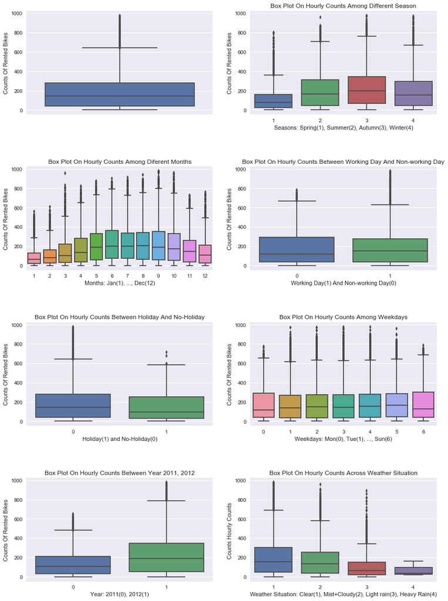

```python
fig, axes = plt.subplots(nrows=4,ncols=2)
fig.set_size_inches(14, 20)
sn.boxplot(data=df_hour, x="cnt", orient="v", ax=axes[0][0])
sn.boxplot(data=df_hour, y="cnt", x="season", orient="v", ax=axes[0][1] )
sn.boxplot(data=df_hour, y="cnt", x="mnth", orient="v", ax=axes[1][0])
sn.boxplot(data=df_hour, y="cnt", x="workingday", orient="v", ax=axes[1][1])
sn.boxplot(data=df_hour, y="cnt", x="holiday", orient="v", ax=axes[2][0] )
sn.boxplot(data=df_hour, y="cnt", x="weekday", orient="v", ax=axes[2][1])
sn.boxplot(data=df_hour, y="cnt", x="yr", orient="v", ax=axes[3][0] )
sn.boxplot(data=df_hour, y="cnt", x="weathersit", orient="v", ax=axes[3][1])

axes[0][0].set(ylabel='Counts Of Rented Bikes')
axes[0][1].set(xlabel='Seasons: Spring(1), Summer(2), Autumn(3), Winter(4)', ylabel='Counts Of Rented Bikes', title="Box Plot On Hourly Counts Among Different Season")
axes[1][0].set(xlabel='Months: Jan(1), ..., Dec(12)', ylabel='Counts Of Rented Bikes', title="Box Plot On Hourly Counts Among Diferent Months")
axes[1][1].set(xlabel='Working Day(1) And Non-working Day(0)', ylabel='Counts Of Rented Bikes', title="Box Plot On Hourly Counts Between Working Day And Non-working Day")
axes[2][0].set(xlabel='Holiday(1) and No-Holiday(0)', ylabel='Counts Of Rented Bikes', title='Box Plot On Hourly Counts Between Holiday And No-Holiday')
axes[2][1].set(xlabel='Weekdays: Mon(0), Tue(1), ..., Sun(6)', ylabel = 'Counts Of Rented Bikes', title='Box Plot On Hourly Counts Among Weekdays')
axes[3][0].set(xlabel='Year: 2011(0), 2012(1)', ylabel='Counts Of Rented Bikes', title='Box Plot On Hourly Counts Between Year 2011, 2012')
axes[3][1].set(xlabel='Weather Situation: Clear(1), Mist+Cloudy(2), Light rain(3), Heavy Rain(4)', ylabel = 'Counts Hourly Counts ', title='Box Plot On Hourly Counts Across Weather Situation')

plt.subplots_adjust(hspace = 0.5)
```

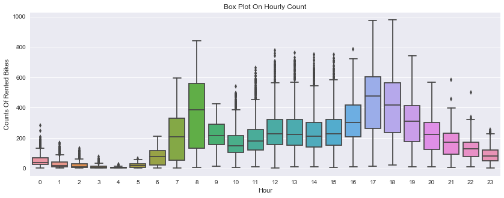

```python
fig, axes= plt.subplots()
fig.set_size_inches(14,5)
sn.boxplot(data=df_hour, y="cnt", x="hr", orient="v", ax= axes )
axes.set(ylabel='Counts Of Rented Bikes', xlabel = 'Hour', title="Box Plot On Hourly Count")
fig.savefig('Box_plot_hourly_count')
```

#### For the hour datsset, I used the box plots to see the outliers. By looking at the box plot on hourly counts, we can see that

- The average counts of rented bikes increases from 5 to 8, then it drops and stay almost the same from 9 to 15 and again increases from 16 to 17 and it drops till midnight.
- On average the during 7-9 in the morining and 16-19 in the afternoon, users rented more bikes compared the other time of the day.
- The max number of rented bikes is at 17 and 18.

#### By looking at the box plot for different seasosn and months, we can observe that

- On average users rent more bikes during summer and autumn from May till October.

#### By looking at the box plot for hourly counts in different weather situation, we can see that

- On average users rent more bikes when the weather is better.

# Histogram for hourly counts of rented bikes

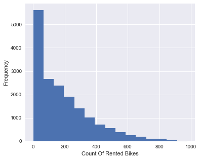

```python
plt.figure(figsize=[6,5])

plt.hist(df_hour['cnt'], bins=15)
plt.xlabel('Count Of Rented Bikes')
plt.ylabel('Frequency')
plt.show()
```

## Correlation matrix for hour dataset

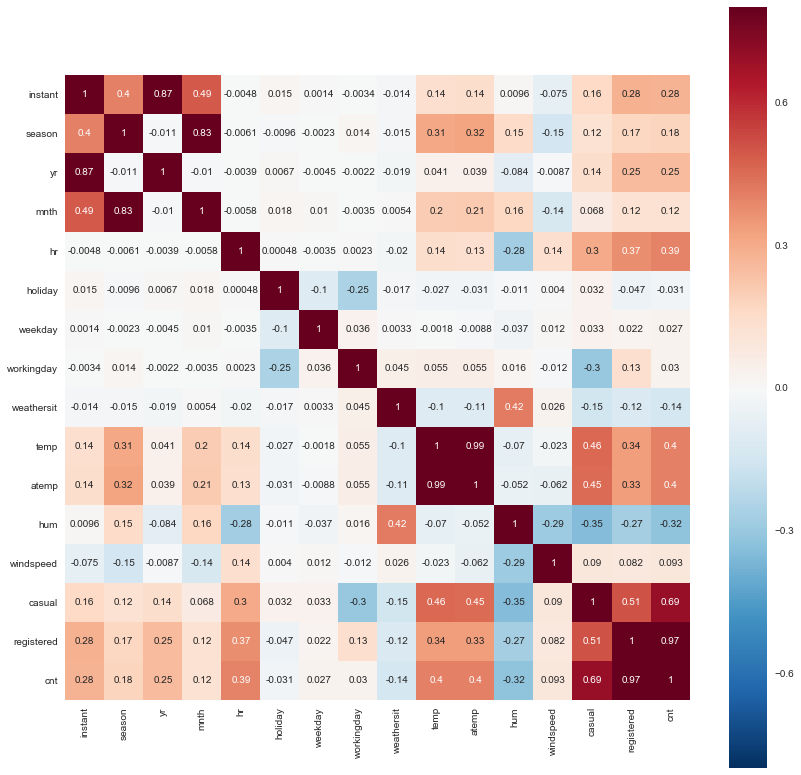

```python
corr = df_hour.corr()

mask = np.zeros_like(corr, dtype=np.bool)
mask[np.triu_indices_from(mask)] = False

f, ax = plt.subplots(figsize=(14, 14))
sn.heatmap(corr, mask=mask, vmax=.8, square=True, annot=True)
```

```python
TOOLS = "pan,wheel_zoom,box_zoom,reset,save,box_select,lasso_select"
output_notebook()

fig = figure( width =900, height= 400,  tools= TOOLS, title= 'Daily Counts Of Users In The Year 2011 and 2012', x_axis_type="datetime")

mask11 = (df_day['dteday'] > '2011-01-01') & (df_day['dteday'] <= '2011-12-31')
df_day_year11 = df_day.loc[mask11]
x_1 = df_day_year11['dteday']
y_1 = df_day_year11['cnt']
fig.line(x_1, y_1,  line_color = 'red', legend='Year 2011')


mask12 = (df_day['dteday'] > '2012-01-01') & (df_day['dteday'] <= '2012-12-31')
df_day_year12 = df_day.loc[mask12]
x_2 = df_day_year12['dteday']
y_2 = df_day_year12['cnt']
fig.line(x_2, y_2,  line_color = 'blue', legend='Year 2012')

show(fig)
```

[interactive chart not shown]

#### As we can see in the plot of daily counts of users in the year 2011 and 2012, there is a cycle in the number of rented bikes. On average users rented more bikes in year 2012, as we can see in the plot below

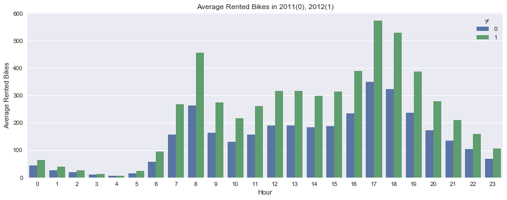

```python
df_hour_year_agg= pd. DataFrame(df_hour.groupby(['hr','yr'], sort = True)['cnt'].mean()).reset_index()

fig, axes= plt.subplots()
fig.set_size_inches(14,5)
sn.barplot(data = df_hour_year_agg, x='hr', y='cnt', hue='yr')
axes.set( xlabel='Hour', ylabel='Average Rented Bikes', title='Average Rented Bikes in 2011(0), 2012(1)')
fig.savefig('avg_rented_bikes_year')
```

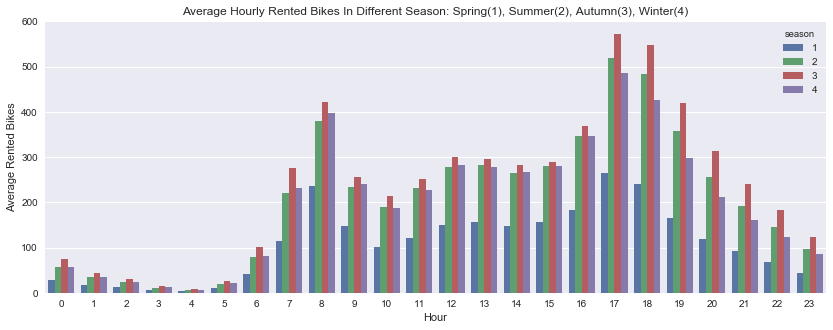

```python
df_hour_month_agg = pd.DataFrame( df_hour.groupby([ 'hr', 'season'], sort = True)['cnt'].mean()).reset_index()

fig, axes= plt.subplots()
fig.set_size_inches(14,5)
sn.barplot(data = df_hour_month_agg, x='hr', y='cnt', hue='season')
axes.set( xlabel='Hour', ylabel='Average Rented Bikes', title='Average Hourly Rented Bikes In Different Season: Spring(1), Summer(2), Autumn(3), Winter(4)')
fig.savefig('avg_rented_bikes_season')
```

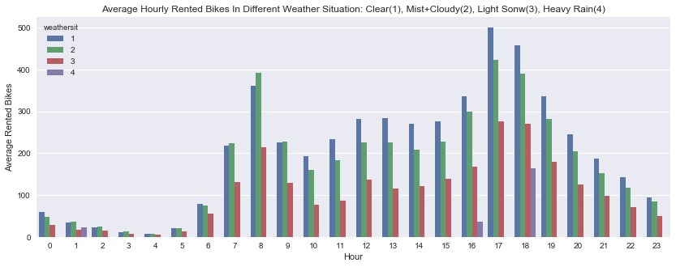

```python
df_hour_weather_agg = pd.DataFrame( df_hour.groupby([ 'hr', 'weathersit'], sort=True)['cnt'].mean()).reset_index()

fig, axes= plt.subplots()
fig.set_size_inches(14,5)
sn.barplot( x='hr', y='cnt', hue='weathersit', data = df_hour_weather_agg)
axes.set( xlabel='Hour', ylabel='Average Rented Bikes', title='Average Hourly Rented Bikes In Different Weather Situation: Clear(1), Mist+Cloudy(2), Light Sonw(3), Heavy Rain(4)')
fig.savefig('avg_rented_bike_weathersit')
```

#### AS we can see users rented more biked when the weather is sunny and clear

# Outliers

## Log transformation for the hourly counts of rented bikes

```python
df_hour['log_cnt'] = np.log(df_hour['cnt'] +1)
```

#### Hourly count before log transformation of counts

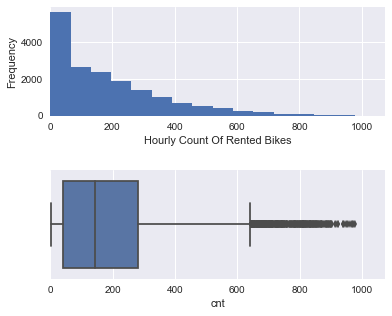

```python
plt.figure(figsize=(6,5))

plt.subplot(211)
plt.xlim(df_hour['cnt'].min(), df_hour['cnt'].max()*1.1)
plt.hist(df_hour['cnt'], bins= 15)
plt.xlabel('Hourly Count Of Rented Bikes')
plt.ylabel('Frequency')

plt.subplot(212)
plt.xlim(0, df_hour['cnt'].max()*1.1)
sn.boxplot(x=df_hour['cnt'])

plt.subplots_adjust(hspace = 0.5)
```

#### Hourly count after log transformation of counts

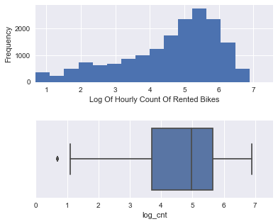

```python
plt.figure(figsize=(6,5))

plt.subplot(211)
plt.xlim(df_hour['log_cnt'].min(), df_hour['log_cnt'].max()*1.1)
plt.hist(df_hour['log_cnt'], bins = 15)
plt.xlabel('Log Of Hourly Count Of Rented Bikes')
plt.ylabel('Frequency')

plt.subplot(212)
plt.xlim(0, df_hour['log_cnt'].max()*1.1)
sn.boxplot(x=df_hour['log_cnt'])

plt.subplots_adjust(hspace = 0.5)
```

#### Finding outliers in our data, if an outlier the value of outlier column equals 1 otherwise it is zero

```python
q3, q1 = np.percentile(df_hour.log_cnt, [75 ,25])
iqr = q3 - q1

min = q1 - (iqr*1.5)
max = q3 + (iqr*1.5)

df_hour['log_outlier'] = 0

df_hour.loc[df_hour['log_cnt'] < min, 'log_outlier'] = 1
df_hour.loc[df_hour['log_cnt'] > max, 'log_outlier'] = 1
```

```python
q3, q1 = np.percentile(df_hour.cnt, [75 ,25])
iqr = q3 - q1

min = q1 - (iqr*1.5)
max = q3 + (iqr*1.5)

df_hour['outlier'] = 0

df_hour.loc[df_hour['cnt'] < min, 'outlier'] = 1
df_hour.loc[df_hour['cnt'] > max, 'outlier'] = 1
```

#### Removing outlier

```python
df_hour_without_outlier = df_hour.loc[df_hour['outlier'] == 0]
df_hour_without_outlier.isnull().sum()
```

```
instant        0
dteday         0
season         0
yr             0
mnth           0
hr             0
holiday        0
weekday        0
workingday     0
weathersit     0
temp           0
atemp          0
hum            0
windspeed      0
casual         0
registered     0
cnt            0
log_cnt        0
log_outlier    0
outlier        0
dtype: int64
```

#### Ine hot encoding for season, hr, weekday and weathersit features

```python
df_hour_without_outlier = pd.merge(df_hour_without_outlier,
          pd.get_dummies(df_hour_without_outlier, columns=['season', 'hr','weekday','weathersit']), how ='inner' )

df_hour_without_outlier = df_hour_without_outlier.drop(labels = ['season', 'hr', 'weekday','weathersit'], axis = 1)
all_col = df_hour_without_outlier.columns
print(all_col)
```

```
Index(['instant', 'dteday', 'yr', 'mnth', 'holiday', 'workingday', 'temp',
       'atemp', 'hum', 'windspeed', 'casual', 'registered', 'cnt', 'log_cnt',
       'log_outlier', 'outlier', 'season_1', 'season_2', 'season_3',
       'season_4', 'hr_0', 'hr_1', 'hr_2', 'hr_3', 'hr_4', 'hr_5', 'hr_6',
       'hr_7', 'hr_8', 'hr_9', 'hr_10', 'hr_11', 'hr_12', 'hr_13', 'hr_14',
       'hr_15', 'hr_16', 'hr_17', 'hr_18', 'hr_19', 'hr_20', 'hr_21', 'hr_22',
       'hr_23', 'weekday_0', 'weekday_1', 'weekday_2', 'weekday_3',
       'weekday_4', 'weekday_5', 'weekday_6', 'weathersit_1', 'weathersit_2',
       'weathersit_3', 'weathersit_4'],
      dtype='object')
```

```python
df_hour_without_outlier.isnull().sum()
```

```
instant         0
dteday          0
yr              0
mnth            0
holiday         0
workingday      0
temp            0
atemp           0
hum             0
windspeed       0
casual          0
registered      0
cnt             0
log_cnt         0
log_outlier     0
outlier         0
season_1        0
season_2        0
season_3        0
season_4        0
hr_0            0
hr_1            0
hr_2            0
hr_3            0
hr_4            0
hr_5            0
hr_6            0
hr_7            0
hr_8            0
hr_9            0
hr_10           0
hr_11           0
hr_12           0
hr_13           0
hr_14           0
hr_15           0
hr_16           0
hr_17           0
hr_18           0
hr_19           0
hr_20           0
hr_21           0
hr_22           0
hr_23           0
weekday_0       0
weekday_1       0
weekday_2       0
weekday_3       0
weekday_4       0
weekday_5       0
weekday_6       0
weathersit_1    0
weathersit_2    0
weathersit_3    0
weathersit_4    0
dtype: int64
```

# Split data into train and test

```python
# Labels are the values we want to predict
labels = np.array(df_hour_without_outlier['cnt'])
#Remove the labels from the features,  axis 1 refers to the columns
features= df_hour_without_outlier.drop(labels = ['instant','dteday','casual','registered', 'cnt', 'log_cnt', 'outlier', 'log_outlier', 'atemp','mnth'],  axis = 1)
# Saving feature names for later use
feature_list = list(features.columns)
print(feature_list)
```

[output not shown]

```python
from sklearn.model_selection import train_test_split
train_features, test_features, train_labels, test_labels = train_test_split(features, labels, test_size = 0.2, random_state = 42)
print('Training Features Shape:', train_features.shape)
print('Training Labels Shape:', train_labels.shape)
print('Testing Features Shape:', test_features.shape)
print('Testing Labels Shape:', test_labels.shape)
```

```
Training Features Shape: (13499, 45)
Training Labels Shape: (13499,)
Testing Features Shape: (3375, 45)
Testing Labels Shape: (3375,)
```

# Regression

```python
from sklearn import linear_model
from sklearn.metrics import mean_squared_error, r2_score

reg = linear_model.LinearRegression()

train_labels_log = np.log(train_labels + 1)
reg.fit(train_features, train_labels_log)

train_labels_pred = np.exp( reg.predict(train_features) )
test_labels_pred = np.exp( reg.predict(test_features) )



rmse_train_regression = np.sqrt(mean_squared_error(train_labels, train_labels_pred))
rmse_test_regression = np.sqrt(mean_squared_error(test_labels, test_labels_pred))
print("Root Mean Squared Error for test set: {}  and train set: {} ". format(rmse_test_regression, rmse_train_regression))

R2_score_test_regression = r2_score(test_labels, test_labels_pred)
print('R2 Score for our test set: %.6f' %R2_score_test_regression)

mean_abs_dev_train_reg = np.mean(np.absolute(train_labels_pred - np.mean(train_labels_pred)))
mean_abs_dev_test_reg = np.mean(np.absolute(test_labels_pred - np.mean(test_labels_pred)))
print('Mean Absolute Deviation for the train set {} and test set {}'.format(mean_abs_dev_train_reg, mean_abs_dev_test_reg))
```

```
Root Mean Squared Error for test set: 89.06734597238204  and train set: 90.54742254530034
R2 Score for our test set: 0.659491
Mean Absolute Deviation for the train set 109.80712426938318 and test set 107.51817514537976
```

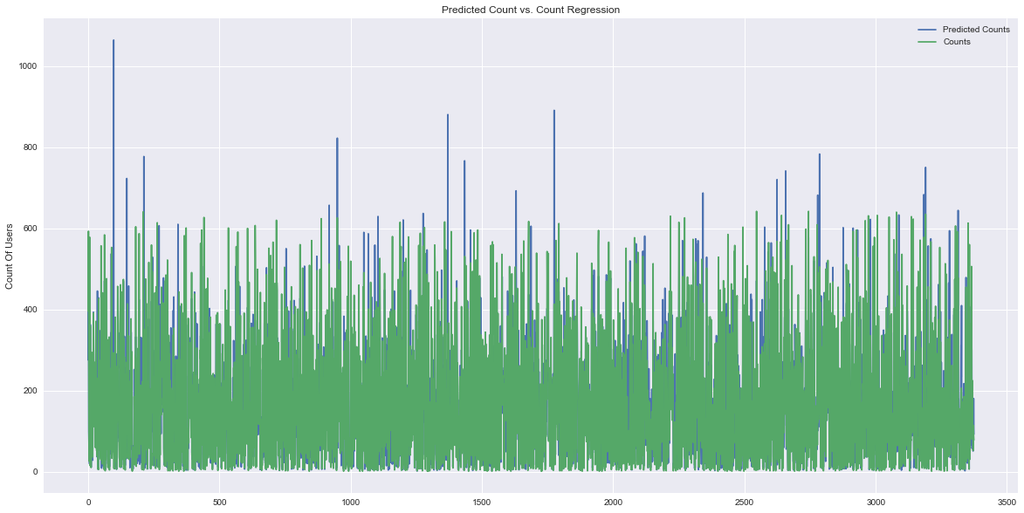

```python
plt.figure(figsize=(20,10))
t = pd.DataFrame({'prediction' : test_labels_pred, 'count' : test_labels.flatten()})
t.sort_values(by=['count'],inplace=False)
plt.plot(t['prediction'].tolist(), label='Predicted Counts')
plt.plot(t['count'].tolist(), label='Counts')
plt.ylabel('Count Of Users')
plt.title('Predicted Count vs. Count Regression')
plt.legend()
```

# Lasso Regression

```python
alpha_list =[0.01, 0.1, 0.2, 0.4, 0.6, 0.8, 1.1, 2, 4, 6, 8, 16]

rmse_train_list_lasso = list()
rmse_test_list_lasso = list()
R2_score_test_list_lasso = list()
mad_list_train_lasso = list()
mad_list_test_lasso =list()

for alpha in alpha_list:
    reg_lasso = linear_model.Lasso(alpha)
    reg_lasso.fit(train_features, train_labels)

    train_labels_pred = reg_lasso.predict(train_features)
    test_labels_pred =  reg_lasso.predict(test_features)

    rmse_train = np.sqrt(mean_squared_error(train_labels, train_labels_pred))
    rmse_train_list_lasso.append(rmse_train)

    rmse_test = np.sqrt(mean_squared_error(test_labels, test_labels_pred))
    rmse_test_list_lasso.append(rmse_test)

    R2_score_test = r2_score(test_labels, test_labels_pred)
    R2_score_test_list_lasso.append(R2_score_test)

    mad_train_lasso = np.mean(np.absolute(train_labels_pred - np.mean(train_labels_pred)))
    mad_list_train_lasso.append(mad_train_lasso)

    mad_test_lasso = np.mean(np.absolute(test_labels_pred - np.mean(test_labels_pred)))
    mad_list_test_lasso.append(mad_test_lasso)


    print("Root Mean Squared Error for test set {} and train set {} for alpha {} \n". format(rmse_test, rmse_train, alpha))
    print('R2 Score for our test set {} for alpha {} \n' .format(R2_score_test, alpha))
    print('Lasso Regression coefficient:\n %s \n'%reg_lasso.coef_)
    print('Mean Absolute Deviation for the train set {} and test set {} for alpha {}\n'.format(mad_train_lasso, mad_test_lasso, alpha))
    print(60*'--')
```

```
Root Mean Squared Error for test set 87.16459591311431 and train set 89.17952232577835 for alpha 0.01

R2 Score for our test set 0.673883942677346 for alpha 0.01

Lasso Regression coefficient:
 [  66.29621842  -21.76830289    0.          215.89325069  -64.21357556
  -29.44133808  -38.68622619    0.          -14.05158056   17.65743324
 -145.44720513 -163.75242565 -174.79898919 -186.41078835 -189.06387135
 -170.02773769 -112.77123488   21.68976584  102.56220571   16.78797626
  -36.29320029  -14.10621225   21.3470676    13.38978421    3.45802593
   11.22898287   77.2601626   164.05391256  141.03430047   85.40729414
   11.19768904  -38.88804245  -76.03194016 -114.98301412   -3.30511596
   -2.31815125   -0.           -0.66077074    0.54472715    9.33157743
    7.21625991   23.35594916   14.95828859  -35.2695993    -0.        ]

Mean Absolute Deviation for the train set 107.14755036519837 and test set 102.84350308581668 for alpha 0.01

------------------------------------------------------------------------------------------------------------------------
Root Mean Squared Error for test set 87.2150345433889 and train set 89.22914141732562 for alpha 0.1

R2 Score for our test set 0.6735064131032975 for alpha 0.1

Lasso Regression coefficient:
 [ 6.58032100e+01 -1.86718450e+01  1.34621128e-02  2.13560980e+02
 -6.51309431e+01 -2.00024456e+01 -3.86533476e+01  6.20278183e-03
 -1.25673142e+01  1.76505055e+01 -1.40577705e+02 -1.58998665e+02
 -1.69887065e+02 -1.81421006e+02 -1.84062686e+02 -1.65099808e+02
 -1.07950857e+02  2.22428190e+01  1.02504840e+02  1.70848066e+01
 -3.18202307e+01 -9.62751952e+00  2.14675217e+01  1.34196334e+01
  3.39621930e+00  1.12251121e+01  7.71839933e+01  1.63418067e+02
  1.40591155e+02  8.56216571e+01  1.15633711e+01 -3.42217067e+01
 -7.13181930e+01 -1.10161683e+02 -2.44133503e+00 -2.02326115e+00
  0.00000000e+00 -0.00000000e+00  0.00000000e+00  8.73446782e+00
  6.60281524e+00  7.98248679e+00  0.00000000e+00 -4.92275540e+01
 -0.00000000e+00]

Mean Absolute Deviation for the train set 105.456790033223 and test set 101.24765255101629 for alpha 0.1

------------------------------------------------------------------------------------------------------------------------
Root Mean Squared Error for test set 87.35938975246549 and train set 89.37231593344205 for alpha 0.2
```

[output cut: 169 more lines]

```
R2 Score for our test set 9.649301747105543e-05 for alpha 16

Lasso Regression coefficient:
 [ 0.         -0.         -0.          0.         -0.          0.
 -0.13641784  0.          0.          0.         -0.         -0.
 -0.         -0.         -0.         -0.         -0.          0.
  0.          0.          0.          0.          0.          0.
  0.          0.          0.          0.          0.          0.
  0.         -0.         -0.         -0.         -0.         -0.
 -0.         -0.          0.          0.          0.          0.
 -0.         -0.         -0.        ]

Mean Absolute Deviation for the train set 0.0512601150718425 and test set 0.050923480694966244 for alpha 16

------------------------------------------------------------------------------------------------------------------------
```

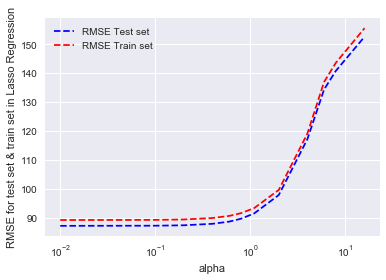

```python
line_up, = plt.plot(alpha_list, rmse_test_list_lasso , 'b--', label='RMSE Test set')
line_down, = plt.plot(alpha_list, rmse_train_list_lasso, 'r--', label='RMSE Train set')
plt.xscale('log')
plt.legend(handles=[line_up, line_down])
plt.xlabel('alpha')
plt.ylabel('RMSE for test set & train set in Lasso Regression')
plt.show()
```

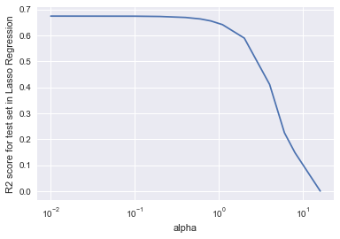

```python
plt.plot(alpha_list, R2_score_test_list_lasso)
plt.xscale('log')
plt.xlabel('alpha')
plt.ylabel('R2 score for test set in Lasso Regression')
plt.show()
```

```python
from sklearn.linear_model import LassoCV

reg = LassoCV(cv=5, random_state=0).fit(train_features, train_labels)
reg.score(train_features, train_labels)
print('alpha parameter of Lasso Regression using cross-validation is:%s \n'%reg.alpha_)

train_labels_pred = reg.predict(train_features)
test_labels_pred =  reg.predict(test_features)

mad_train_lasso = np.mean(np.absolute(train_labels_pred - np.mean(train_labels_pred)))
mad_test_lasso = np.mean(np.absolute(test_labels_pred - np.mean(test_labels_pred)))
print('Mean Absolute Deviation for the train set {} and test set {}'.format(mad_train_lasso, mad_test_lasso))
```

```
alpha parameter of Lasso Regression using cross-validation is:0.019757145763937976

Mean Absolute Deviation for the train set 106.96288776445934 and test set 102.66971669709696
```

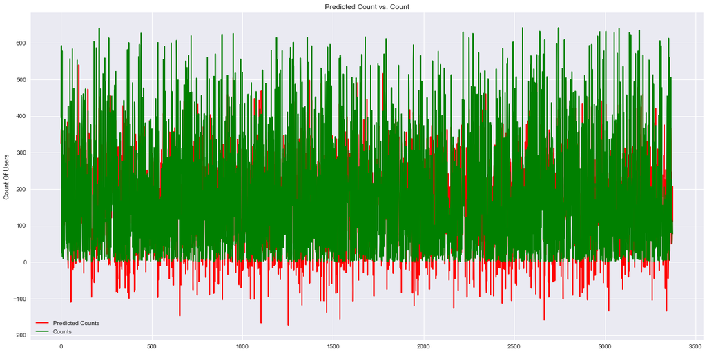

```python
plt.figure(figsize=(20,10))
t = pd.DataFrame({'prediction' : test_labels_pred, 'count' : test_labels.flatten()})
t.sort_values(by=['count'],inplace=False)
plt.plot(t['prediction'].tolist(), label='Predicted Counts', color='r')
plt.plot(t['count'].tolist(), label='Counts', color ='green')
plt.ylabel('Count Of Users')
plt.title('Predicted Count vs. Count')
plt.legend()
```

# Setting the regularization parameter for Ridge Regression

```python
from sklearn import linear_model
reg = linear_model.RidgeCV(alphas=[0.1, 0.2, 0.4, 0.6, 0.8, 1.1, 2, 3, 4, 8, 10, 20, 40, 60], cv=5)
reg.fit(train_features, train_labels)
print('Regularization parameter for Ridge Regression: %s'%reg.alpha_ )
```

```
Regularization parameter for Ridge Regression: 2
```

# Ridge Regression

```python
from sklearn.linear_model import Ridge

alpha_list =[0.01, 0.1, 0.2, 0.3, 0.4,0.6,0.8, 1, 2]
rmse_train_list_ridge = list()
rmse_test_list_ridge = list()
R2_score_test_list_ridge = list()
mad_list_train_ridge = list()
mad_list_test_ridge = list()
for alpha in alpha_list:
    reg_ridge = linear_model.Ridge(alpha)
    reg_ridge.fit(train_features, train_labels)

    train_labels_pred = reg_ridge.predict(train_features)
    test_labels_pred =  reg_ridge.predict(test_features)

    rmse_train = np.sqrt(mean_squared_error(train_labels, train_labels_pred))
    rmse_train_list_ridge.append(rmse_train)

    rmse_test= np.sqrt(mean_squared_error(test_labels, test_labels_pred))
    rmse_test_list_ridge.append(rmse_test)

    mad_train_ridge = np.mean(np.absolute(train_labels_pred - np.mean(train_labels_pred)))
    mad_list_train_ridge.append(mad_train_ridge)

    mad_test_ridge = np.mean(np.absolute(test_labels_pred - np.mean(test_labels_pred)))
    mad_list_test_ridge.append(mad_test_ridge)


    R2_score_test = r2_score(test_labels, test_labels_pred)
    R2_score_test_list_ridge.append(R2_score_test)

    print("Root Mean Squared Error for test set {} and train set {} for alpha {}\n". format(rmse_test, rmse_train, alpha))
    print('R2 Score for our test set for alpha {} is:  {}\n ' .format(alpha, R2_score_test))
    print('Mean Absolute Deviation for the train set {} and test set {}\n'.format(mad_train_ridge, mad_test_ridge

                                                                                 ))
    print(60*'--')
```

```
Root Mean Squared Error for test set 87.16405708718808 and train set 89.17746498460083 for alpha 0.01

R2 Score for our test set for alpha 0.01 is:  0.6738879745722153

Mean Absolute Deviation for the train set 107.33564649830858 and test set 103.01961034973091

------------------------------------------------------------------------------------------------------------------------
Root Mean Squared Error for test set 87.16452380099327 and train set 89.17746872934983 for alpha 0.1

R2 Score for our test set for alpha 0.1 is:  0.673884482275118

Mean Absolute Deviation for the train set 107.32131823312824 and test set 103.00603768081777

------------------------------------------------------------------------------------------------------------------------
Root Mean Squared Error for test set 87.1650477044695 and train set 89.17747988159209 for alpha 0.2

R2 Score for our test set for alpha 0.2 is:  0.6738805620204226

Mean Absolute Deviation for the train set 107.30540332613285 and test set 102.99095925865467

------------------------------------------------------------------------------------------------------------------------
Root Mean Squared Error for test set 87.16557715680825 and train set 89.17749813734872 for alpha 0.3

R2 Score for our test set for alpha 0.3 is:  0.6738766002208689

Mean Absolute Deviation for the train set 107.28949413018665 and test set 102.97588351042634

------------------------------------------------------------------------------------------------------------------------
Root Mean Squared Error for test set 87.16611209665322 and train set 89.17752326578909 for alpha 0.4

R2 Score for our test set for alpha 0.4 is:  0.6738725973348231

Mean Absolute Deviation for the train set 107.2735918200466 and test set 102.96081065316501

------------------------------------------------------------------------------------------------------------------------
Root Mean Squared Error for test set 87.16719821685558 and train set 89.17759336166415 for alpha 0.6

R2 Score for our test set for alpha 0.6 is:  0.6738644699614925

Mean Absolute Deviation for the train set 107.24180997699732 and test set 102.93067438306502
```

[output cut: 8 more lines]

```
------------------------------------------------------------------------------------------------------------------------
Root Mean Squared Error for test set 87.16943408001863 and train set 89.17780869172971 for alpha 1

R2 Score for our test set for alpha 1 is:  0.6738477388106763

Mean Absolute Deviation for the train set 107.17832040660029 and test set 102.870444134671

------------------------------------------------------------------------------------------------------------------------
Root Mean Squared Error for test set 87.17538126481212 and train set 89.17875072890887 for alpha 2

R2 Score for our test set for alpha 2 is:  0.6738032334411799

Mean Absolute Deviation for the train set 107.02009420985978 and test set 102.72019508956761

------------------------------------------------------------------------------------------------------------------------
```

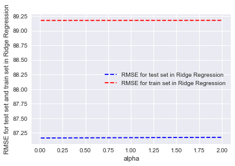

```python
line_up, = plt.plot(alpha_list, rmse_test_list_ridge , 'b--', label = 'RMSE for test set in Ridge Regression')
line_down, = plt.plot(alpha_list, rmse_train_list_ridge, 'r--', label = 'RMSE for train set in Ridge Regression')
plt.legend(handles=[line_up, line_down])
plt.xlabel('alpha')
plt.ylabel('RMSE for test set and train set in Ridge Regression')
plt.show()
```

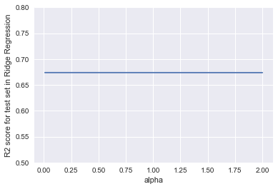

```python
plt.plot(alpha_list, R2_score_test_list_ridge)
plt.xlabel('alpha')
plt.ylabel('R2 score for test set in Ridge Regression')
plt.ylim(bottom=0.5, top=0.8 )
plt.show()
```

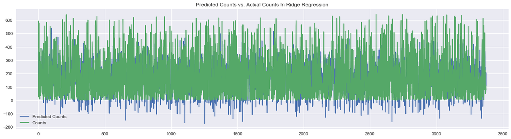

```python
plt.figure(figsize=(20,5))
t = pd.DataFrame({'prediction' : test_labels_pred, 'count' : test_labels.flatten()})
t.sort_values(by=['count'],inplace=False)
plt.plot(t['prediction'].tolist(), label='Predicted Counts')
plt.plot(t['count'].tolist(), label='Counts')
plt.title('Predicted Counts vs. Actual Counts In Ridge Regression')
plt.legend()
```

# Random Forest Regressor

```python
from sklearn.ensemble import RandomForestRegressor
max_depth = [2,3,4,5,6,7,8, 9 ,10 , 11]
R2_score_test_list_randomforest = []
rmse_train_list_randomforest = []
rmse_test_list_randomforest = []
mad_list_train_rf = []
mad_list_test_rf = []
for depth in max_depth:
    regr = RandomForestRegressor(max_depth=depth, random_state=1 )
    regr.fit(train_features, train_labels)

    test_labels_pred = regr.predict(test_features)
    train_labels_pred = regr.predict(train_features)


    rmse_train = np.sqrt(mean_squared_error(train_labels, train_labels_pred))
    rmse_train_list_randomforest.append(rmse_train)

    rmse_test= np.sqrt(mean_squared_error(test_labels, test_labels_pred))
    rmse_test_list_randomforest.append(rmse_test)

    mad_train_rf = np.mean(np.absolute(train_labels_pred - np.mean(train_labels_pred)))
    mad_list_train_rf.append(mad_train_rf)

    mad_test_rf = np.mean(np.absolute(test_labels_pred - np.mean(test_labels_pred)))
    mad_list_test_rf.append(mad_test_rf)


    R2_score_test = r2_score(test_labels, test_labels_pred)
    R2_score_test_list_randomforest.append(R2_score_test)

    print("Root Mean Squared Error for test set {} and train set {} for the tree with depth {}\n". format(rmse_test, rmse_train, depth))
    print('R2 score for our test set: %.6f \n' %R2_score_test)
    print('Mean Absolute Deviation for the train set {} and test set {}\n'.format(mad_train_rf, mad_test_rf))
    print(60*'--')
```

```
Root Mean Squared Error for test set 132.96616584682525 and train set 135.76627703013435 for the tree with depth 2

R2 score for our test set: 0.241118

Mean Absolute Deviation for the train set 50.25990977864367 and test set 50.10756465954125

------------------------------------------------------------------------------------------------------------------------
Root Mean Squared Error for test set 126.52915176909242 and train set 128.53864889867026 for the tree with depth 3

R2 score for our test set: 0.312816

Mean Absolute Deviation for the train set 64.68935184944941 and test set 64.24454469467128

------------------------------------------------------------------------------------------------------------------------
Root Mean Squared Error for test set 118.12571278427086 and train set 120.20969015842884 for the tree with depth 4

R2 score for our test set: 0.401063

Mean Absolute Deviation for the train set 69.31832962053248 and test set 68.06681619805187

------------------------------------------------------------------------------------------------------------------------
Root Mean Squared Error for test set 110.37648798150596 and train set 112.0513876072064 for the tree with depth 5

R2 score for our test set: 0.477068

Mean Absolute Deviation for the train set 73.81269910547613 and test set 71.73910613094421

------------------------------------------------------------------------------------------------------------------------
Root Mean Squared Error for test set 102.17557175806986 and train set 103.04628191729304 for the tree with depth 6

R2 score for our test set: 0.551888

Mean Absolute Deviation for the train set 77.95498028337244 and test set 75.63703163614302

------------------------------------------------------------------------------------------------------------------------
Root Mean Squared Error for test set 95.24530682721755 and train set 94.93035615565134 for the tree with depth 7

R2 score for our test set: 0.610615

Mean Absolute Deviation for the train set 83.05943066716343 and test set 79.92301140575597
```

[output cut: 15 more lines]

```
------------------------------------------------------------------------------------------------------------------------
Root Mean Squared Error for test set 78.6737659075667 and train set 74.80138385000461 for the tree with depth 10

R2 score for our test set: 0.734324

Mean Absolute Deviation for the train set 94.62551224283088 and test set 90.20058436973486

------------------------------------------------------------------------------------------------------------------------
Root Mean Squared Error for test set 74.55350179767096 and train set 69.32435762366732 for the tree with depth 11

R2 score for our test set: 0.761423

Mean Absolute Deviation for the train set 98.27464965951174 and test set 93.78212673570962

------------------------------------------------------------------------------------------------------------------------
```

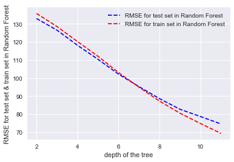

```python
line_up, = plt.plot(max_depth, rmse_test_list_randomforest , 'b--', label = 'RMSE for test set in Random Forest')
line_down, = plt.plot(max_depth, rmse_train_list_randomforest, 'r--', label = 'RMSE for train set in Random Forest')
plt.legend(handles=[line_up, line_down])
plt.xlabel('depth of the tree')
plt.ylabel('RMSE for test set & train set in Random Forest')
plt.savefig('RMSE_RF.png')
plt.show()
```

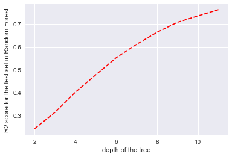

```python
plt.plot(max_depth, R2_score_test_list_randomforest , 'r--')
plt.xlabel('depth of the tree')
plt.ylabel('R2 score for the test set in Random Forest')
plt.savefig('R2_RF.png')
plt.show()
```

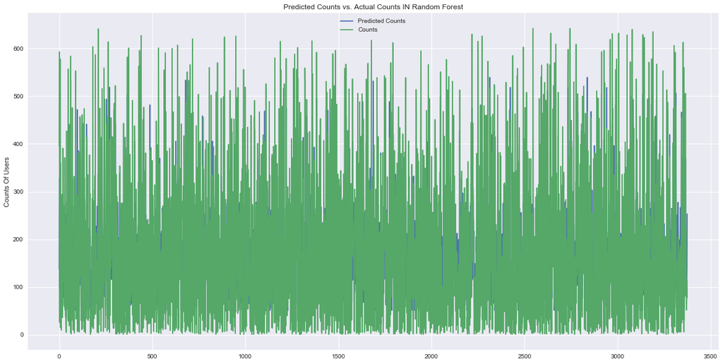

```python
regr = RandomForestRegressor(max_depth=6, random_state=1 )
regr.fit(train_features, train_labels)

test_labels_pred = regr.predict(test_features)
train_labels_pred = regr.predict(train_features)

plt.figure(figsize=(20,10))
t = pd.DataFrame({'prediction' : test_labels_pred, 'count' : test_labels.flatten()})
t.sort_values(by=['count'],inplace=False)
plt.plot(t['prediction'].tolist(), label='Predicted Counts')
plt.plot(t['count'].tolist(), label='Counts')
plt.title('Predicted Counts vs. Actual Counts IN Random Forest')
plt.ylabel('Counts Of Users')
plt.legend()
```

# Gradient Boosting Regressor

```python
from sklearn.ensemble import GradientBoostingRegressor

estimators = np.arange(30, 200, 10)
R2_score_test_list_gbr = []
rmse_train_list_gbr = []
rmse_test_list_gbr = []
mad_list_train_gbr = []
mad_list_test_gbr = []

for n in estimators:
    model = GradientBoostingRegressor(n_estimators=n, learning_rate=0.1, max_depth=1, random_state=0, loss='ls')
    model.fit(train_features, train_labels)


    test_labels_pred = model.predict(test_features)
    train_labels_pred = model.predict(train_features)

    rmse_train = np.sqrt(mean_squared_error(train_labels, train_labels_pred))
    rmse_train_list_gbr.append(rmse_train)

    rmse_test= np.sqrt(mean_squared_error(test_labels, test_labels_pred))
    rmse_test_list_gbr.append(rmse_test)

    mad_train_gbr = np.mean(np.absolute(train_labels_pred - np.mean(train_labels_pred)))
    mad_list_train_gbr.append(mad_train_gbr)

    mad_test_gbr = np.mean(np.absolute(test_labels_pred - np.mean(test_labels_pred)))
    mad_list_test_gbr.append(mad_test_gbr)

    R2_score_test = r2_score(test_labels, test_labels_pred)
    R2_score_test_list_gbr.append(R2_score_test)

    print("Root Mean Squared Error for test set {} and train set {} for {} estimators\n". format(rmse_test, rmse_train, n))
    print('R2 Score for our test set: %.6f\n' %R2_score_test)
    print('Mean Absolute Deviation for the train set {} and test set {}\n'.format(mad_train_gbr, mad_test_gbr))
    print(60*'--')
```

```
Root Mean Squared Error for test set 130.23969072858497 and train set 132.68954956387682 for 30 estimators

R2 Score for our test set: 0.271921

Mean Absolute Deviation for the train set 33.642238429306126 and test set 33.06134351962385

------------------------------------------------------------------------------------------------------------------------
Root Mean Squared Error for test set 125.8755114530085 and train set 128.11852421982223 for 40 estimators

R2 Score for our test set: 0.319897

Mean Absolute Deviation for the train set 37.6860883419229 and test set 36.94966782557224

------------------------------------------------------------------------------------------------------------------------
Root Mean Squared Error for test set 122.01376096824885 and train set 124.13970905354202 for 50 estimators

R2 Score for our test set: 0.360987

Mean Absolute Deviation for the train set 41.30651857421763 and test set 40.32656250457887

------------------------------------------------------------------------------------------------------------------------
Root Mean Squared Error for test set 118.59981544357984 and train set 120.59302530197145 for 60 estimators

R2 Score for our test set: 0.396246

Mean Absolute Deviation for the train set 45.729720190973666 and test set 44.556865205234814

------------------------------------------------------------------------------------------------------------------------
Root Mean Squared Error for test set 115.57360943079962 and train set 117.46437262161342 for 70 estimators

R2 Score for our test set: 0.426664

Mean Absolute Deviation for the train set 49.44478153439427 and test set 48.11922670888066

------------------------------------------------------------------------------------------------------------------------
Root Mean Squared Error for test set 113.00585900923903 and train set 114.74336341691486 for 80 estimators

R2 Score for our test set: 0.451857

Mean Absolute Deviation for the train set 53.05357775875546 and test set 51.47242151862607
```

[output cut: 64 more lines]

```
------------------------------------------------------------------------------------------------------------------------
Root Mean Squared Error for test set 97.38410048544569 and train set 98.99931293176397 for 180 estimators

R2 Score for our test set: 0.592931

Mean Absolute Deviation for the train set 75.73608280733535 and test set 73.27483126875525

------------------------------------------------------------------------------------------------------------------------
Root Mean Squared Error for test set 96.54062270065279 and train set 98.1529273201257 for 190 estimators

R2 Score for our test set: 0.599952

Mean Absolute Deviation for the train set 77.5861811670589 and test set 75.0550726675956

------------------------------------------------------------------------------------------------------------------------
```

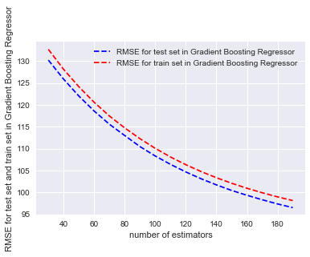

```python
line_up, = plt.plot(estimators, rmse_test_list_gbr , 'b--', label = 'RMSE for test set in Gradient Boosting Regressor')
line_down, = plt.plot(estimators, rmse_train_list_gbr, 'r--', label = 'RMSE for train set in Gradient Boosting Regressor')
plt.legend(handles=[line_up, line_down])
plt.xlabel('number of estimators')
plt.ylabel('RMSE for test set and train set in Gradient Boosting Regressor')
plt.show()
```

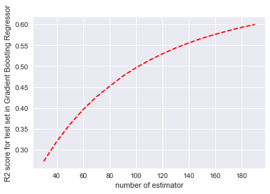

```python
plt.plot(estimators, R2_score_test_list_gbr, 'r--')
plt.xlabel('number of estimator')
plt.ylabel('R2 score for test set in Gradient Boosting Regressor')
plt.show()
```

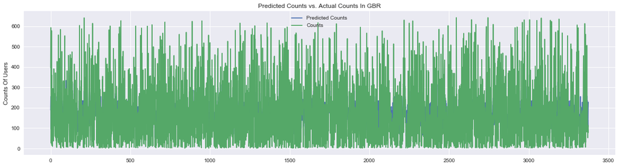

```python
model = GradientBoostingRegressor(n_estimators=60, learning_rate=0.1, max_depth=1, random_state=0, loss='ls')
model.fit(train_features, train_labels)


test_labels_pred = model.predict(test_features)
train_labels_pred = model.predict(train_features)
plt.figure(figsize=(20,5))
t = pd.DataFrame({'prediction' : test_labels_pred, 'count' : test_labels.flatten()})
t.sort_values(by=['count'],inplace=False)
plt.plot(t['prediction'].tolist(), label='Predicted Counts')
plt.plot(t['count'].tolist(), label='Counts')
plt.title('Predicted Counts vs. Actual Counts In GBR')
plt.ylabel('Counts Of Users')
plt.legend()
```

# Choosing the model

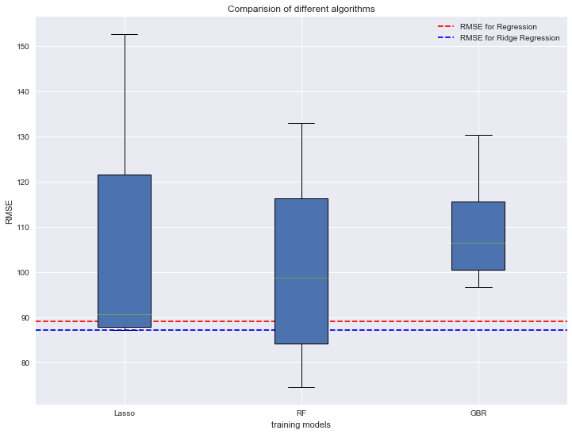

```python
fig = plt.figure(1, figsize=(12, 9))
plt.boxplot(x=[ rmse_test_list_lasso, rmse_test_list_randomforest, rmse_test_list_gbr ],
            labels=[  'Lasso', 'RF', 'GBR'], patch_artist=True)
baseline_1 = plt.axhline(y=rmse_test_regression, color='r', linestyle='--', label='RMSE for Regression')
baseline_2 = plt.axhline(y=rmse_test_list_ridge[-1], color='b', linestyle='--', label='RMSE for Ridge Regression')
plt.legend(handles=[baseline_1, baseline_2])
plt.ylabel('RMSE')
plt.xlabel('training models')
plt.title('Comparision of different algorithms')
fig.savefig('boxplot.png')
plt.show()
```

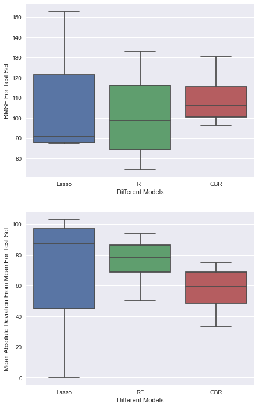

```python
fig, axes = plt.subplots(nrows=2,ncols=1)
fig.set_size_inches(7, 12)
#baseline = plt.axhline(y=rmse_test_list_ridge[2], color='r', linestyle='--', label='RMSE for Ridge Regression')
#plt.legend(handles=[baseline])
sn.boxplot(x=[ 'Lasso', 'RF', 'GBR'], y=[rmse_test_list_lasso, rmse_test_list_randomforest, rmse_test_list_gbr ], orient="v", ax=axes[0])
sn.boxplot(x=[ 'Lasso', 'RF', 'GBR'], y=[mad_list_test_lasso, mad_list_test_rf, mad_list_test_gbr], orient="v", ax=axes[1])

axes[0].set(xlabel='Different Models', ylabel='RMSE For Test Set')
axes[1].set(xlabel='Different Models', ylabel = 'Mean Absolute Deviation From Mean For Test Set')
fig.savefig('Box_plot_model_selection.png')
```